# Introduction to Tidyverse

Oct 10, 2017

## What is Tidyverse?

### Packages

- **dplyr** (data manipulation)
- **ggplot2** (visualization)
- tidyr, readr, purrr, tibble

## `dplyr`

## Essentials of dplyr

Five fundamental words and you can do almost anything.

- `select` / `rename`
- `filter` / `distinct`
- `arrange`
- `mutate` / `transmute`
- `group-by` + `summarize`

and the pipe operator `%>%` to bind them all.

## Preparation

We are going to use `secimler` package as a data source and apply `dplyr` commmands. (See [instructions to install](https://berkorbay.github.io/secimler/).)

```r
library(tidyverse)
library(secimler)
secim150607g  #Our data set
```

```
## # A tibble: 176,831 x 30
##       il bolge   ilce               cevre cevre_turu sandik kayitli_secmen
##    <chr> <dbl>  <chr>               <chr>      <chr>  <dbl>          <dbl>
##  1 Adana     1    İli               Genel     Toplam   4426        1477328
##  2 Adana     1    İli       İl-İlçe Genel     Toplam   4426        1477328
##  3 Adana     1 Seyhan               Genel     Toplam   1473         529658
##  4 Adana     1 Seyhan       İl-İlçe Genel     Toplam   1473         529658
##  5 Adana     1 Seyhan Ahmet Remzi Yüreğir    Mahalle   3001            341
##  6 Adana     1 Seyhan Ahmet Remzi Yüreğir    Mahalle   3002            339
##  7 Adana     1 Seyhan Ahmet Remzi Yüreğir    Mahalle   3003            341
##  8 Adana     1 Seyhan              Akkapı    Mahalle   2001            366
##  9 Adana     1 Seyhan              Akkapı    Mahalle   2002            365
## 10 Adana     1 Seyhan              Akkapı    Mahalle   2003            366
## # ... with 176,821 more rows, and 23 more variables: oy_kullanan <dbl>,
## #   gecerli_oy <dbl>, ak_parti <dbl>, chp <dbl>, mhp <dbl>, hdp <dbl>,
## #   dyp <dbl>, anadolu_partisi <dbl>, hak_par <dbl>, kp <dbl>,
## #   millet_partisi <dbl>, hap <dbl>, mep <dbl>, turk_parti <dbl>,
## #   hkp <dbl>, ldp <dbl>, saadet_partisi <dbl>, dsp <dbl>,
## #   yurt_parti <dbl>, dp <dbl>, vatan_partisi <dbl>, btp <dbl>,
## #   bagimsiz <dbl>
```

## A `glimpse` of the data

`glimpse` is similar to `str`.

```r
glimpse(secim150607g)
```

```
## Observations: 176,831
## Variables: 30
## $ il              <chr> "Adana", "Adana", "Adana", "Adana", "Adana", "...
## $ bolge           <dbl> 1, 1, 1, 1, 1, 1, 1, 1, 1, 1, 1, 1, 1, 1, 1, 1...
## $ ilce            <chr> "İli", "İli", "Seyhan", "Seyhan", "Seyhan", "S...
## $ cevre           <chr> "Genel", "İl-İlçe Genel", "Genel", "İl-İlçe Ge...
## $ cevre_turu      <chr> "Toplam", "Toplam", "Toplam", "Toplam", "Mahal...
## $ sandik          <dbl> 4426, 4426, 1473, 1473, 3001, 3002, 3003, 2001...
## $ kayitli_secmen  <dbl> 1477328, 1477328, 529658, 529658, 341, 339, 34...
## $ oy_kullanan     <dbl> 1254393, 1254393, 449743, 449743, 285, 278, 29...
## $ gecerli_oy      <dbl> 1229817, 1229817, 441384, 441384, 279, 270, 28...
## $ ak_parti        <dbl> 368055, 368055, 113966, 113966, 111, 98, 88, 1...
## $ chp             <dbl> 354389, 354389, 138646, 138646, 49, 59, 67, 28...
## $ mhp             <dbl> 287799, 287799, 79714, 79714, 81, 66, 81, 4, 4...
## $ hdp             <dbl> 177730, 177730, 94887, 94887, 29, 35, 49, 9, 5...
```

[output cut: 17 more lines]

## `select` / `rename`

It is basically column select and renaming.

```r
secim150607g %>% select(il, cevre, kayitli_secmen)
```

```
## # A tibble: 176,831 x 3
##       il               cevre kayitli_secmen
##    <chr>               <chr>          <dbl>
##  1 Adana               Genel        1477328
##  2 Adana       İl-İlçe Genel        1477328
##  3 Adana               Genel         529658
##  4 Adana       İl-İlçe Genel         529658
##  5 Adana Ahmet Remzi Yüreğir            341
##  6 Adana Ahmet Remzi Yüreğir            339
##  7 Adana Ahmet Remzi Yüreğir            341
##  8 Adana              Akkapı            366
##  9 Adana              Akkapı            365
## 10 Adana              Akkapı            366
## # ... with 176,821 more rows
```

## `select` / `rename`

```r
secim150607g %>% rename(city = il)
```

```
## # A tibble: 176,831 x 30
##     city bolge   ilce               cevre cevre_turu sandik kayitli_secmen
##    <chr> <dbl>  <chr>               <chr>      <chr>  <dbl>          <dbl>
##  1 Adana     1    İli               Genel     Toplam   4426        1477328
##  2 Adana     1    İli       İl-İlçe Genel     Toplam   4426        1477328
##  3 Adana     1 Seyhan               Genel     Toplam   1473         529658
##  4 Adana     1 Seyhan       İl-İlçe Genel     Toplam   1473         529658
##  5 Adana     1 Seyhan Ahmet Remzi Yüreğir    Mahalle   3001            341
##  6 Adana     1 Seyhan Ahmet Remzi Yüreğir    Mahalle   3002            339
##  7 Adana     1 Seyhan Ahmet Remzi Yüreğir    Mahalle   3003            341
##  8 Adana     1 Seyhan              Akkapı    Mahalle   2001            366
##  9 Adana     1 Seyhan              Akkapı    Mahalle   2002            365
## 10 Adana     1 Seyhan              Akkapı    Mahalle   2003            366
## # ... with 176,821 more rows, and 23 more variables: oy_kullanan <dbl>,
## #   gecerli_oy <dbl>, ak_parti <dbl>, chp <dbl>, mhp <dbl>, hdp <dbl>,
## #   dyp <dbl>, anadolu_partisi <dbl>, hak_par <dbl>, kp <dbl>,
## #   millet_partisi <dbl>, hap <dbl>, mep <dbl>, turk_parti <dbl>,
## #   hkp <dbl>, ldp <dbl>, saadet_partisi <dbl>, dsp <dbl>,
## #   yurt_parti <dbl>, dp <dbl>, vatan_partisi <dbl>, btp <dbl>,
## #   bagimsiz <dbl>
```

## `select` / `rename`

You can rename with select also.

```r
secim150607g %>% select(city = il, district = cevre, n_voters = kayitli_secmen)
```

```
## # A tibble: 176,831 x 3
##     city            district n_voters
##    <chr>               <chr>    <dbl>
##  1 Adana               Genel  1477328
##  2 Adana       İl-İlçe Genel  1477328
##  3 Adana               Genel   529658
##  4 Adana       İl-İlçe Genel   529658
##  5 Adana Ahmet Remzi Yüreğir      341
##  6 Adana Ahmet Remzi Yüreğir      339
##  7 Adana Ahmet Remzi Yüreğir      341
##  8 Adana              Akkapı      366
##  9 Adana              Akkapı      365
## 10 Adana              Akkapı      366
## # ... with 176,821 more rows
```

## `filter` / `distinct`

`filter` returns the rows given the criteria.

```r
secim150607g %>% filter(il == "İstanbul")
```

```
## # A tibble: 27,977 x 30
##          il bolge   ilce          cevre cevre_turu sandik kayitli_secmen
##       <chr> <dbl>  <chr>          <chr>      <chr>  <dbl>          <dbl>
##  1 İstanbul     1    İli          Genel     Toplam  10055        3682297
##  2 İstanbul     1    İli  İl-İlçe Genel     Toplam  10055        3682297
##  3 İstanbul     1 Adalar          Genel     Toplam     37          12087
##  4 İstanbul     1 Adalar  İl-İlçe Genel     Toplam     37          12087
##  5 İstanbul     1 Adalar    Burgazadası    Mahalle   1001            309
##  6 İstanbul     1 Adalar    Burgazadası    Mahalle   1002            312
##  7 İstanbul     1 Adalar    Burgazadası    Mahalle   1003            310
##  8 İstanbul     1 Adalar    Burgazadası    Mahalle   1004            310
##  9 İstanbul     1 Adalar Büyükada-Maden    Mahalle   1005            277
## 10 İstanbul     1 Adalar Büyükada-Maden    Mahalle   1006            275
## # ... with 27,967 more rows, and 23 more variables: oy_kullanan <dbl>,
## #   gecerli_oy <dbl>, ak_parti <dbl>, chp <dbl>, mhp <dbl>, hdp <dbl>,
## #   dyp <dbl>, anadolu_partisi <dbl>, hak_par <dbl>, kp <dbl>,
## #   millet_partisi <dbl>, hap <dbl>, mep <dbl>, turk_parti <dbl>,
## #   hkp <dbl>, ldp <dbl>, saadet_partisi <dbl>, dsp <dbl>,
## #   yurt_parti <dbl>, dp <dbl>, vatan_partisi <dbl>, btp <dbl>,
## #   bagimsiz <dbl>
```

## `filter` / `distinct`

```r
secim150607g %>% filter(il == "İzmir" & kayitli_secmen > 99 &
    kayitli_secmen <= 300)
```

```
## # A tibble: 925 x 30
##       il bolge  ilce         cevre cevre_turu sandik kayitli_secmen
##    <chr> <dbl> <chr>         <chr>      <chr>  <dbl>          <dbl>
##  1 İzmir     1 Çeşme         Ardıç    Mahalle   1026            191
##  2 İzmir     1 Çeşme         Ardıç    Mahalle   1027            192
##  3 İzmir     1 Çeşme       Boyalık    Mahalle   1028            199
##  4 İzmir     1 Çeşme       Boyalık    Mahalle   1029            199
##  5 İzmir     1 Çeşme   Celal Bayar    Mahalle   1030            257
##  6 İzmir     1 Çeşme   Celal Bayar    Mahalle   1031            255
##  7 İzmir     1 Çeşme       Çakabey    Mahalle   1034            138
##  8 İzmir     1 Çeşme Fahrettinpaşa    Mahalle   1044            279
##  9 İzmir     1 Çeşme         Ildır    Mahalle   1048            275
## 10 İzmir     1 Çeşme         Ildır    Mahalle   1049            276
## # ... with 915 more rows, and 23 more variables: oy_kullanan <dbl>,
## #   gecerli_oy <dbl>, ak_parti <dbl>, chp <dbl>, mhp <dbl>, hdp <dbl>,
## #   dyp <dbl>, anadolu_partisi <dbl>, hak_par <dbl>, kp <dbl>,
## #   millet_partisi <dbl>, hap <dbl>, mep <dbl>, turk_parti <dbl>,
## #   hkp <dbl>, ldp <dbl>, saadet_partisi <dbl>, dsp <dbl>,
## #   yurt_parti <dbl>, dp <dbl>, vatan_partisi <dbl>, btp <dbl>,
## #   bagimsiz <dbl>
```

## `filter` / `distinct`

`distinct` removes the duplicate values.

```r
secim150607g %>% distinct(il, .keep_all = TRUE)
```

```
## # A tibble: 81 x 30
##                il bolge  ilce cevre cevre_turu sandik kayitli_secmen
##             <chr> <dbl> <chr> <chr>      <chr>  <dbl>          <dbl>
##  1          Adana     1   İli Genel     Toplam   4426        1477328
##  2       Adıyaman     1   İli Genel     Toplam   1386         380745
##  3 Afyonkarahisar     1   İli Genel     Toplam   1766         493765
##  4           Ağrı     1   İli Genel     Toplam   1153         291539
##  5         Amasya     1   İli Genel     Toplam    916         238506
##  6         Ankara     1   İli Genel     Toplam   5936        2074389
##  7        Antalya     1   İli Genel     Toplam   4691        1568153
##  8         Artvin     1   İli Genel     Toplam    621         129961
##  9          Aydın     1   İli Genel     Toplam   2452         772649
## 10      Balıkesir     1   İli Genel     Toplam   3100         906421
## # ... with 71 more rows, and 23 more variables: oy_kullanan <dbl>,
## #   gecerli_oy <dbl>, ak_parti <dbl>, chp <dbl>, mhp <dbl>, hdp <dbl>,
## #   dyp <dbl>, anadolu_partisi <dbl>, hak_par <dbl>, kp <dbl>,
## #   millet_partisi <dbl>, hap <dbl>, mep <dbl>, turk_parti <dbl>,
## #   hkp <dbl>, ldp <dbl>, saadet_partisi <dbl>, dsp <dbl>,
## #   yurt_parti <dbl>, dp <dbl>, vatan_partisi <dbl>, btp <dbl>,
## #   bagimsiz <dbl>
```

## `arrange`

`arrange` is to order by columns.

```r
secim150607g %>% distinct(il, .keep_all = TRUE) %>% arrange(desc(kayitli_secmen))
```

```
## # A tibble: 81 x 30
##           il bolge  ilce cevre cevre_turu sandik kayitli_secmen
##        <chr> <dbl> <chr> <chr>      <chr>  <dbl>          <dbl>
##  1  İstanbul     1   İli Genel     Toplam  10055        3682297
##  2    Ankara     1   İli Genel     Toplam   5936        2074389
##  3     Bursa     1   İli Genel     Toplam   5968        2028417
##  4   Antalya     1   İli Genel     Toplam   4691        1568153
##  5     İzmir     1   İli Genel     Toplam   4304        1513998
##  6     Adana     1   İli Genel     Toplam   4426        1477328
##  7     Konya     1   İli Genel     Toplam   4523        1430306
##  8   Kocaeli     1   İli Genel     Toplam   3577        1221771
##  9    Mersin     1   İli Genel     Toplam   3698        1210552
## 10 Gaziantep     1   İli Genel     Toplam   3462        1130109
## # ... with 71 more rows, and 23 more variables: oy_kullanan <dbl>,
## #   gecerli_oy <dbl>, ak_parti <dbl>, chp <dbl>, mhp <dbl>, hdp <dbl>,
## #   dyp <dbl>, anadolu_partisi <dbl>, hak_par <dbl>, kp <dbl>,
## #   millet_partisi <dbl>, hap <dbl>, mep <dbl>, turk_parti <dbl>,
## #   hkp <dbl>, ldp <dbl>, saadet_partisi <dbl>, dsp <dbl>,
## #   yurt_parti <dbl>, dp <dbl>, vatan_partisi <dbl>, btp <dbl>,
## #   bagimsiz <dbl>
```

## `mutate` / `transmute`

`mutate` is used to do operations on columns.

```r
secim150607g %>% distinct(il, .keep_all = TRUE) %>% select(il,
    sandik, kayitli_secmen, gecerli_oy) %>% mutate(katilim = round(gecerli_oy/kayitli_secmen,
    2))
```

```
## # A tibble: 81 x 5
##                il sandik kayitli_secmen gecerli_oy katilim
##             <chr>  <dbl>          <dbl>      <dbl>   <dbl>
##  1          Adana   4426        1477328    1229817    0.83
##  2       Adıyaman   1386         380745     306562    0.81
##  3 Afyonkarahisar   1766         493765     424884    0.86
##  4           Ağrı   1153         291539     237172    0.81
##  5         Amasya    916         238506     209549    0.88
##  6         Ankara   5936        2074389    1797588    0.87
##  7        Antalya   4691        1568153    1306778    0.83
##  8         Artvin    621         129961     108191    0.83
##  9          Aydın   2452         772649     658731    0.85
## 10      Balıkesir   3100         906421     786183    0.87
## # ... with 71 more rows
```

## `mutate` / `transmute`

`transmute` is `mutate` + `select`.

```r
secim150607g %>% distinct(il, .keep_all = TRUE) %>% transmute(il,
    sandik, katilim = round(gecerli_oy/kayitli_secmen, 2))
```

```
## # A tibble: 81 x 3
##                il sandik katilim
##             <chr>  <dbl>   <dbl>
##  1          Adana   4426    0.83
##  2       Adıyaman   1386    0.81
##  3 Afyonkarahisar   1766    0.86
##  4           Ağrı   1153    0.81
##  5         Amasya    916    0.88
##  6         Ankara   5936    0.87
##  7        Antalya   4691    0.83
##  8         Artvin    621    0.83
##  9          Aydın   2452    0.85
## 10      Balıkesir   3100    0.87
## # ... with 71 more rows
```

## `group_by` / `summarise`

Analogous to pivot table.

```r
secim150607g %>% filter(cevre_turu != "Toplam") %>% group_by(cevre_turu) %>%
    summarise(count = n(), gecerli_oy = sum(gecerli_oy), kayitli_secmen = sum(kayitli_secmen),
        katilim = round(sum(gecerli_oy)/sum(kayitli_secmen),
            2))
```

```
## # A tibble: 4 x 5
##   cevre_turu  count gecerli_oy kayitli_secmen katilim
##        <chr>  <int>      <dbl>          <dbl>   <dbl>
## 1      Belde   2954     666967         799165    0.83
## 2    Cezaevi    343      30610              0     Inf
## 3        Köy  21631    3140794        3692727    0.85
## 4    Mahalle 149292   41283402       49249946    0.84
```

## `dplyr` extras

- Some extensively used extra words: `slice`, `sample_n`, `sample_frac`, `mutate_at`, `summarise_at`.
- Table join operations `left_join`, `semi_join`, `full_join`, `anti_join`.
- Wide/long formats with `spread`, `gather`.
- Repetitive tasks with `ddply`, `adply`, `mdply` and `ldply`.

See course webpage for more examples and implementations. Definitely get dplyr cheat sheet.

## `ggplot2`

## What is `ggplot2`?

`gg` stands for grammar of graphics.

```r
# Instead of %>% we use + for ggplot2.
ggplot(data = data_set, aes(x = x_axis_col, y = y_axis_col)) +
    geom_point()
```

- `geom_point` scatter plot.
- `geom_bar` bar charts and pie charts.
- `geom_line` line charts.
- `geom_boxplot` box plots.
- `geom_tile` heatmaps.
- `geom_histogram` histograms.
- `geom_dotplot`, `geom_polygon`, `geom_density`,`geom_contour`,`geom_ribbon`,`geom_area`,…

## Prepare data

```r
the_df <- secim150607g %>% filter(il == "İzmir" & !(cevre_turu %in%
    c("Cezaevi", "Toplam"))) %>% transmute(county = ilce, district = cevre,
    district_type = cevre_turu, participation = gecerli_oy/kayitli_secmen,
    n_voters = kayitli_secmen, n_valid_votes = gecerli_oy)
the_df
```

```
## # A tibble: 8,963 x 6
##    county district district_type participation n_voters n_valid_votes
##     <chr>    <chr>         <chr>         <dbl>    <dbl>         <dbl>
##  1  Çeşme  Alaçatı       Mahalle     0.8442623      366           309
##  2  Çeşme  Alaçatı       Mahalle     0.8879781      366           325
##  3  Çeşme  Alaçatı       Mahalle     0.8060109      366           295
##  4  Çeşme  Alaçatı       Mahalle     0.9068493      365           331
##  5  Çeşme  Alaçatı       Mahalle     0.7788162      321           250
##  6  Çeşme  Alaçatı       Mahalle     0.8317757      321           267
##  7  Çeşme  Alaçatı       Mahalle     0.8535826      321           274
##  8  Çeşme  Alaçatı       Mahalle     0.7962382      319           254
##  9  Çeşme  Alaçatı       Mahalle     0.7994100      339           271
## 10  Çeşme  Alaçatı       Mahalle     0.8230088      339           279
## # ... with 8,953 more rows
```

## `geom_point`

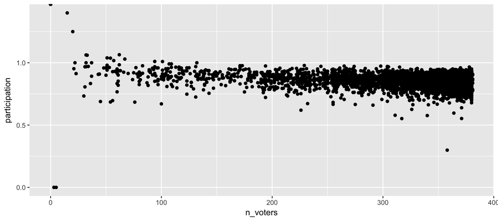

```r
ggplot(data = the_df, aes(x = n_voters, y = participation)) +
    geom_point()
```

## `geom_bar`

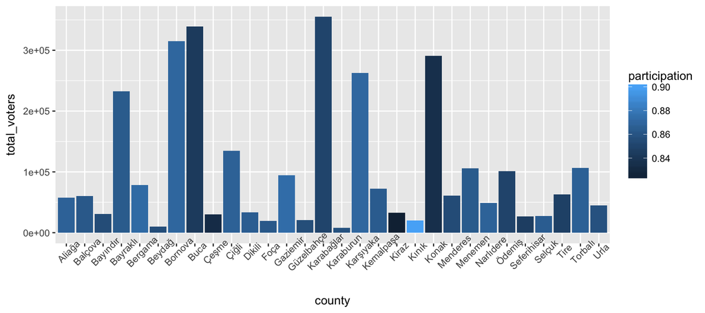

```r
ggplot(data = the_df %>% group_by(county) %>% summarise(participation = weighted.mean(participation,
    n_voters), total_voters = sum(n_voters)), aes(x = county,
    y = total_voters, fill = participation)) + geom_bar(stat = "identity") +
    theme(axis.text.x = element_text(angle = 45))
```

## `geom_bar` pie chart

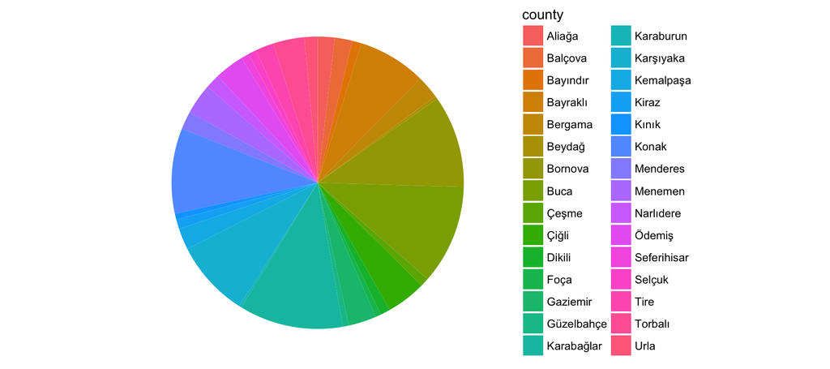

```r
ggplot(data = the_df %>% group_by(county) %>% summarise(total_voters = sum(n_voters)),
    aes(x = "", y = total_voters, fill = county)) + geom_bar(stat = "identity",
    width = 1) + coord_polar("y", direction = -1) + theme_void()
```

## `ggplot2` extras

- `theme` adds and modifies style.
- `fill`, `alpha`, `color`, `shape` parameters.
- Extension packages such as `ggthemes`, `ggnetwork` etc.
- Add trend lines with `abline`, or fit splines with `geom_smooth`.
- Interactive plots with `plotly` package.

See course webpage for extra materials. Definitely get cheat sheet.

Note: ggplot2 is very easy for basic stuff. But as requirements get complex, it might need more attention.

## RMarkdown and Other Packages

## RMarkdown

- RMarkdown is very easy to learn
- Things you can do with RMarkdown is amazing.
- RStudio makes it very easy to work with RMarkdown.
- You will be provided with enough material to learn RMarkdown basics.
- You will be asked to do almost everything with RMarkdown.

## Other Packages

There are some other amazing packages that you can use in your data processes. This is not an exhaustive but definitely delightful list.

- `lubridate` is good for time data.
- `stringr` for string data.
- `readxl` and `writexl` for xlsx files i/o operations.
- `rvest` for parsing from web sites.
- `haven`, `readr`, `DBI`, `foreign` for different file types.
- `devtools`, `roxygen2` for package making and documentation.
- `data.table`, `sparklyr` for big data stuff.
- `shiny` for web pages.